# Assignment 1 CITS5508

Author: Nicodemus Ong

Student Number: 22607943

## 1 Outline

In this assignment, you will develop Python code for classification tasks using logistic regression and k-NN classifiers. You will use Grid Search and cross-validation to find the optimal hyperparameters of the model (e.g., the regularisation hyperparameter) and discus and interpret the different decisions and their impact on the model’s performance and interpretability.

## 2 Submission

Your submission consists of a two files. The first file is a report describing your analysis/approach. Your analysis should provide the requested plots and tables and your explanations and reflections about the results. Each deliverable task is indicated as D, a number and associated marks. For instance, D1 [3 marks] is the first deliverable task, and it is worth three marks.

The second file is your Python notebook with the code supporting the part one analysis. It will follow the rules provided in LMS. Your report should be submitted as “.PDF” file. Name your file as assig1 .pdf (where you should replace with your student ID) and submit it to LMS before the due date and time. You can submit your file multiple times. Only the latest version will be marked. Ac- cordingly, your code should be submitted as assig1 .ipynb, the Jupyter notebook extension.

**Important**:

- You must submit the first part of your assignment as an electronic file and use a PDF format (do not send DOCX or any other file format). Only PDF format is accepted. Any other file format will get a zero mark.
- You must deliver part one and part two to have your assignment assessed. That is, your submission should contain your analysis and your Jupyter notebook with all coding, both with appropriate formatting.
- By submitting your assignment, you acknowledge you have read all instructions provided in this document and in LMS.
- There is a section in your LMS, Assignments - Assignment 1 - Updates, where you will find updates or clarifications about the tasks when necessary. It is your responsibility to check this page regularly.
- You will be assessed on your thinking and process, not only on your results. A perfect performance without demonstrating understanding what you have done won’t provide you marks.
- Your answer must be concise. Two to three sentences should be enough to answer most of the open questions. If you are writing long answers, rethink what you are doing. Probably, it is the wrong path.
- You can ask in the lab or during consultation if you need any clarification about the assignment questions.
- You should be aware that some algorithms can take a while to run. A good approach to improving their speed in Python is to use the vectorised forms discussed in class. In this case, it is strongly recommended that you start your assignment soon to accommodate the computational time.
- For the functions and tasks that require a random procedure (e.g. splitting the data into 80% training and 20% validation set), you should set the seed of the random generator to the value “5508”.

## 3 Dataset

Fashion-MNIST is a dataset motivated by the popular MNIST dataset used to classify handwritten digits. It contains examples of ten classes (e.g. sneakers, coats, sandals, trousers, pullovers, etc.). Fashion-MNIST has a training set with 60,000 examples and a test set with 10,000 examples. Each example is a 28 x 28 low-resolution and grayscale image (similar to the examples in MNIST) associated with a label from one of the ten classes.

In LMS, you will find four predefined datasets to support your tasks in this assignment:

- FMNIST training set.csv: Training set with 60,000 examples of the cloth items.
- FMNIST training set labels.csv: Labels associated to each example in FMNIST training set.csv.
- FMNIST test set.csv: Testing set with 10,000 examples of cloth items.
- FMNIST test set labels.csv: Labels associated to each example in FMNIST test set.csv.

Each input image in the files FMNIST training set.csv and FMNIST test set classes.csv: follows the same representation as in the MNIST dataset; that is, each example is a 28 x 28 gray-scale image re- shaped into a 784-dimensional vector. Each input image has a label associated with it, given by the files FMNIST test set labels.csv (training set labels) and FMNIST test set labels.csv (test set labels). Each pixel’s feature value can assume values in the range of 0.0 (black) and 1.0 (white). Feature values in between this range represent the possible variation in grey. Therefore, each example i has features xi ∈ R784 and target feature (label) yi ∈ {0, 1, 2, 3, 4, 5, 6, 7, 8, 9}. The parametric space has bias and weights, which is in dimension 785.

## 4 Problem: Classifying Sneakers versus Sandals

We will start with a binary classification using the Fashion-MNIST dataset. In this problem, your challenge is to build a logistic regression classifier that generalises well to distinguish Sneakers from Sandals, and you will need to demonstrate you know how to load the data, train a logistic regression classifier and interpret the results.

### 4.1 Summarising the datasets

From the files provided for the large Fashion-MNIST dataset, write a Python code to separate images from “sneakers” and “sandals”. You should create a training set containing “sneakers” and “sandals” only, from FMNIST training set.csv, and a respectively training set labels where each yi should be 0 (zero) for “sneakers” and 1 for “sandals” (binary problem). Accordingly, you should create a test set containing “sneakers” and “sandals”, from FMNIST test set.csv, and a respectively test set labels where each yi ∈ {0, 1}.

You should not reorder, sample, or change your data. You will need to build new data, but the original characteristics and data order must be preserved.

**Note**: For this assignment I have opted to scale the data using the StandardScalar() function. The primary motive of doing so is to:

- Boost performance and computational speed. Pixel values in images can range from 0 to 255. When using machine learning algorithms that compute distances or assume normality, having features on the same scale can help the algorithm converge more quickly and perform more accurately.
- It ensures that the gradient descent moves smoothly towards the minima and helps the algorithm to converge faster. Without scaling, features with larger ranges could disproportionately influence the gradient updates and cause the optimizer to oscillate.
- For algorithms like k-Nearest Neighbors (k-NN), which rely on distance calculations, having features on different scales can distort the distance measurements. For example, if one pixel tends to have higher values or greater variance than others, it might disproportionately affect the distance computations.
- When regularization is used (like L1 or L2 regularization in logistic regression), it applies penalties to the size of the coefficients associated with each feature. If the features are on different scales, the regularization term can unfairly penalize some features more than others, simply due to the scale and not the actual importance of the feature.

```python
import pandas as pd
import numpy as np
import seaborn as sns
import matplotlib.pyplot as plt
from sklearn.linear_model import LogisticRegressionCV
from sklearn.model_selection import train_test_split, cross_val_score
from sklearn.metrics import f1_score, confusion_matrix, roc_curve, auc, accuracy_score, precision_score, recall_score
from sklearn.metrics import make_scorer, log_loss, precision_recall_curve, PrecisionRecallDisplay
from sklearn.linear_model import SGDClassifier
from sklearn.model_selection import GridSearchCV
from sklearn.exceptions import ConvergenceWarning
from sklearn.preprocessing import StandardScaler
import math
import warnings
from sklearn.neighbors import KNeighborsClassifier
```

Run data Transformation steps:

```python
# Read in data
df_train = pd.read_csv("/Users/nathanielong/Desktop/cits5508/assignments/assignment1/FMNIST_training_set.csv", header=None)
df_test = pd.read_csv("/Users/nathanielong/Desktop/cits5508/assignments/assignment1/FMNIST_test_set.csv", header=None)

# Read in labels
df_train_labels = pd.read_csv("/Users/nathanielong/Desktop/cits5508/assignments/assignment1/FMNIST_training_set_labels.csv", header=None)
df_test_labels = pd.read_csv("/Users/nathanielong/Desktop/cits5508/assignments/assignment1/FMNIST_test_set_labels.csv", header=None)
```

```python
# Merge the dataframes
df_train_merged = pd.concat([df_train_labels, df_train], axis=1)
df_test_merged = pd.concat([df_test_labels, df_test], axis=1)
```

```python
# Filter and keep only rows where the first column has values 5 or 7
filtered_train_df = df_train_merged[df_train_merged.iloc[:, 0].isin([5, 7])]
filtered_test_df = df_test_merged[df_test_merged.iloc[:, 0].isin([5, 7])]
```

```python
# Replace 5s with 1s and 7s with 0s in the first column
filtered_train_df.iloc[:, 0] = filtered_train_df.iloc[:, 0].replace({5: 1, 7: 0})
filtered_test_df.iloc[:, 0] = filtered_test_df.iloc[:, 0].replace({5: 1, 7: 0})
```

#### D1 [3 marks]:

In a table, describe:

- The number of instances in the training set; • The number of instances in the test set;
- The total number of instances.

```python
# Number of instances in the training set
num_instances_train = filtered_train_df.shape[0]

# Number of instances in the test set
num_instances_test = filtered_test_df.shape[0]

# Total number of instances
total_instances = num_instances_train + num_instances_test

# Create a dictionary to hold the data
data = {
    "Training Set": [num_instances_train],
    "Test Set": [num_instances_test],
    "Total": [total_instances]
}

# Convert the dictionary to a DataFrame
df = pd.DataFrame(data)

# Print the DataFrame
df
```

|  | Training Set | Test Set | Total |
| --- | --- | --- | --- |
| 0 | 11988 | 2000 | 13988 |

##### D1 Answer:

As we can see after processing, there are a total number of 11988 instances in the Training Set and 2000 in the Test Set totaling up to 13988 instances.

#### D2 [2 marks]:

Provide a bar plot showing the number of instances for each class label. Do you have an imbalanced training set?

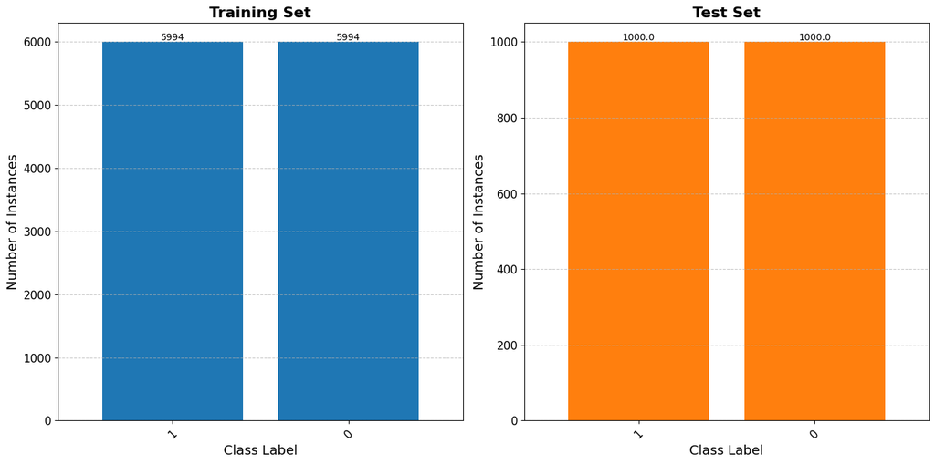

```python
# Count the occurrences of each class label in the filtered training and test sets
train_class_counts = filtered_train_df.iloc[:, 0].value_counts()
test_class_counts = filtered_test_df.iloc[:, 0].value_counts()

# Create a figure with two subplots
fig, axes = plt.subplots(nrows=1, ncols=2, figsize=(14, 7), dpi=100)

# Enhancements: Custom colors and bar width
colors_train = ['#1f77b4'] * len(train_class_counts)
colors_test = ['#ff7f0e'] * len(test_class_counts)

# Plot for the training set
train_bars = train_class_counts.plot(kind='bar', ax=axes[0], color=colors_train, width=0.8)
axes[0].set_title('Training Set', fontsize=16, fontweight='bold')
axes[0].set_xlabel('Class Label', fontsize=14)
axes[0].set_ylabel('Number of Instances', fontsize=14)
axes[0].grid(axis='y', linestyle='--', alpha=0.7)
axes[0].tick_params(axis='x', rotation=45)
axes[0].tick_params(axis='both', which='major', labelsize=12)

# Annotate bar values for the training set
for bar in train_bars.patches:
    axes[0].annotate(format(bar.get_height(), '.0f'),
                     (bar.get_x() + bar.get_width() / 2,
                      bar.get_height()), ha='center', va='center',
                     xytext=(0, 5), textcoords='offset points', fontsize=10)

# Plot for the test set
test_bars = test_class_counts.plot(kind='bar', ax=axes[1], color=colors_test, width=0.8)
axes[1].set_title('Test Set', fontsize=16, fontweight='bold')
axes[1].set_xlabel('Class Label', fontsize=14)
axes[1].set_ylabel('Number of Instances', fontsize=14)
axes[1].grid(axis='y', linestyle='--', alpha=0.7)
axes[1].tick_params(axis='x', rotation=45)
axes[1].tick_params(axis='both', which='major', labelsize=12)

# Annotate bar values for the test set
for bar in test_bars.patches:
    axes[1].annotate(format(bar.get_height(), '.1f'),
                     (bar.get_x() + bar.get_width() / 2,
                      bar.get_height()), ha='center', va='center',
                     xytext=(0, 5), textcoords='offset points', fontsize=10)

# Adjust layout and show plot with a tighter layout
plt.tight_layout()

plt.show()
```

##### D2 Answer:

No we do not, both the training and validation set are equal in both binary classes.

#### D3 [3 marks]:

Plot the first six images/examples from each class with the corresponding example id and associated label on the top of the plot. Use Python function imshow() (you may need to adjust some values for the arguments in the function imshow() to better visualise the resulting image). Hint: use a 3 x 4 grid. In the example below, we attributed class ‘1’ to the sandals and class ‘0’ to the sneakers.

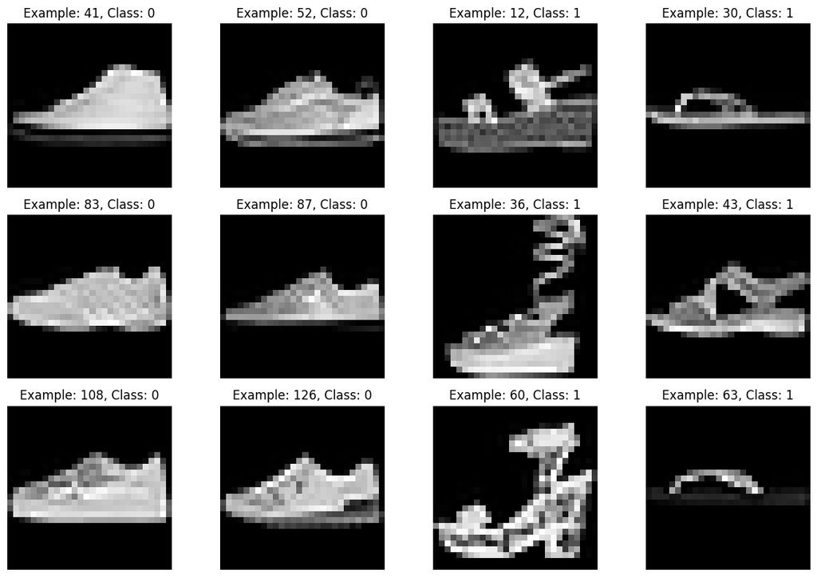

```python
# Plotting the first six images for each class
fig, axs = plt.subplots(3, 4, figsize=(12, 8)) # Adjusting the figure size for better visibility

for i, label in enumerate([0, 1]):
    # Filter the DataFrame for the current label and take the first 6 images
    label_df = filtered_train_df[filtered_train_df.iloc[:, 0] == label].head(6)

    for j, (index, row) in enumerate(label_df.iterrows()):
        ax = axs[j // 2, (j % 2) + (i * 2)] # Correctly indexing axes
        img = row[1:].values.reshape(28, 28) # Reshape the flattened image data. Adjust if your image size is different
        ax.imshow(img, cmap='gray') # Plot the image
        ax.set_title(f"Example: {index}, Class: {label}") # Set title with ID and Label
        ax.axis('off') # Hide axes for clarity

plt.tight_layout()
plt.show()
```

### 4.2 Fitting your logistic regression classifier

In this part, you will check how your classifier behaves using an iterative optimization algorithm to fit the training data. You will implement the Logistic Regression Classifier with Batch Gradient Descent. Split your training data (that you constructed on “summarising the datasets”) into two sets: training and validation. Select randomly 80% for training and 20% for validation. You must set the random generator seed to “5508” before the splitting. Ensure your validation set is fixed and does not change each time you run your algorithm. Your implementation should initialise η (the learning rate) and θ (the parameter vector). Then, in each iteration, the main steps will look like:

gradients = ... # calculate the gradient vector using all instances

theta = ... # update the parameter vector

est_p = ... # compute the estimated probability for each instance

lr_cost_function = ... # calculate the logistic regression cost function

The probability pˆ estimated by the logistic regression model is given by: pˆ = hθ(x) = σ(θ⊤x) = 1 1 + exp(−θ⊤x)

#### D4 [3 marks]:

Experiment with some values for η, the learning rate of the gradient descent. Provide plots to support your decision for the final value and justify your choice.

```python
X = filtered_train_df.iloc[:, 1:]
y = filtered_train_df.iloc[:, 0]
```

```python
X_train, X_val, y_train, y_val = train_test_split(X, y, test_size=0.2, random_state=5508)
```

```python
# Initialize the scaler
scaler = StandardScaler()
# Fit the scaler to the training data only
X_train_scaled = scaler.fit_transform(X_train)
# Transform the test data with the same scaler
X_val_scaled = scaler.transform(X_val)
```

```python
def sigmoid(z):
    return 1 / (1 + np.exp(-z))

def compute_cost(X, y, weights):
    m = len(y)
    h = sigmoid(X.dot(weights))
    epsilon = 1e-5  # to prevent log(0)
    cost = (-1/m) * (y.T.dot(np.log(h + epsilon)) + (1 - y).T.dot(np.log(1 - h + epsilon)))
    return cost

def compute_gradient(X, y, weights):
    m = X.shape[0]
    h = sigmoid(X.dot(weights))
    gradient = (1/m) * X.T.dot(h - y)
    return gradient

def predict_class(X, weights):
    probabilities = sigmoid(X.dot(weights))
    return probabilities >= 0.5

def misclassification_rate(y_true, y_pred):
    return np.mean(y_pred != y_true)
```

```python
# Suppress Warnings that may occur
warnings.filterwarnings("ignore", category=RuntimeWarning)

# Declare fit function
def fit(X_train, y_train, X_val, y_val, learning_rate=0.01, n_iterations=10000):
    X_train = np.copy(X_train)
    X_val = np.copy(X_val)

    m, n = X_train.shape
    X_train = np.hstack([np.ones((m, 1)), X_train])  # Add bias term to training set
    m_val = X_val.shape[0]
    X_val = np.hstack([np.ones((m_val, 1)), X_val])  # Add bias term to validation set

    weights = np.zeros(n + 1)  # Initialize weights (including bias)
    train_costs = []
    val_costs = []
    train_misclassifications = []
    val_misclassifications = []

    for i in range(n_iterations):
        # Update weights using the training set
        gradients = compute_gradient(X_train, y_train, weights)
        weights -= learning_rate * gradients

        # Calculate costs
        train_cost = compute_cost(X_train, y_train, weights)
        val_cost = compute_cost(X_val, y_val, weights)
        train_costs.append(train_cost)
        val_costs.append(val_cost)

        # Calculate misclassification rates
        train_pred = predict_class(X_train, weights)
        val_pred = predict_class(X_val, weights)
        train_misclassifications.append(misclassification_rate(y_train, train_pred))
        val_misclassifications.append(misclassification_rate(y_val, val_pred))

        if i % 1000 == 0:
            print(f"Iteration: {i}")
    return train_pred, val_pred, train_costs, val_costs, train_misclassifications, val_misclassifications
```

```python
learning_rates = [0.0001,0.0002,0.0003,0.0004,0.0005]
train_pred_dict, val_pred_dict, costs_train_dict, costs_val_dict, misclassification_rates_train_dict, misclassification_rates_val_dict = {}, {}, {}, {}, {}, {}
for lr in learning_rates:
    train_pred, val_pred, costs_train, misclassification_rate_train, costs_val, misclassification_rate_val = fit(X_train_scaled, y_train, X_val_scaled, y_val, learning_rate=lr, n_iterations=10000)

    train_pred_dict[lr] = train_pred
    val_pred_dict[lr] = val_pred
    costs_train_dict[lr] = costs_train
    misclassification_rates_train_dict[lr] = misclassification_rate_train
    costs_val_dict[lr] = costs_val
    misclassification_rates_val_dict[lr] = misclassification_rate_val
```

```
Iteration: 0
```

[output not shown]

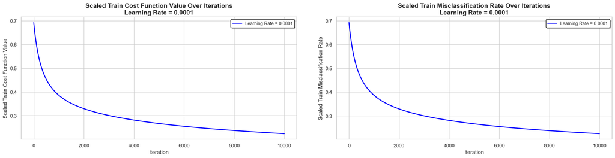

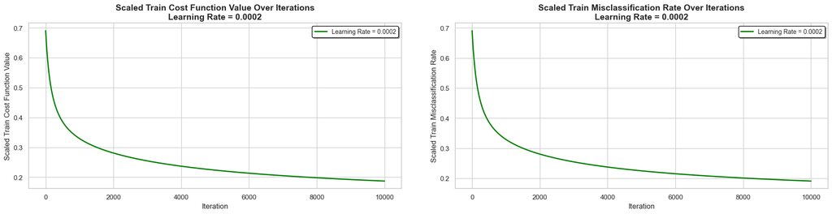

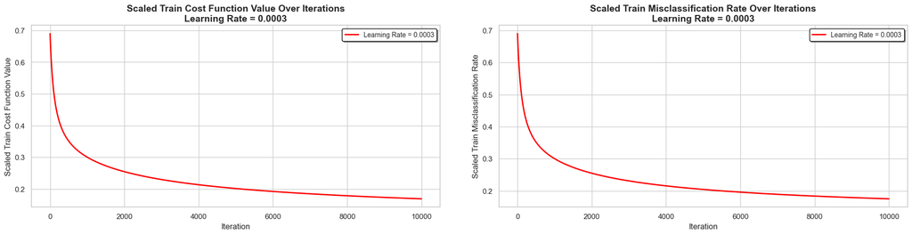

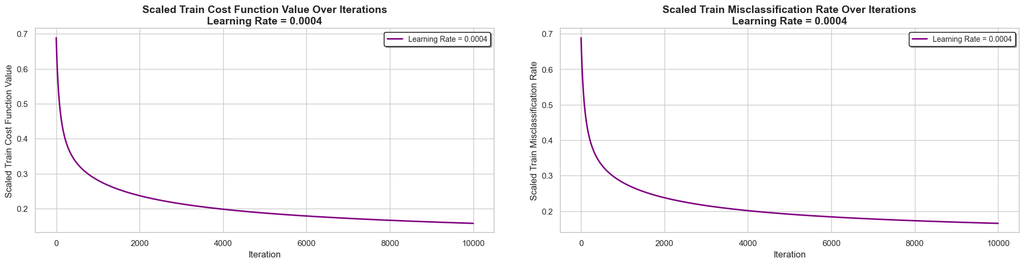

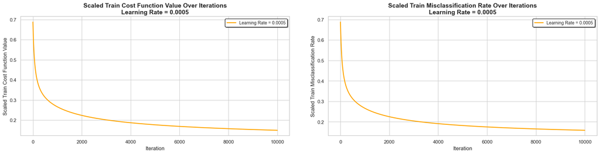

```python
# Applying a seaborn theme for nicer aesthetics
sns.set_theme(style="whitegrid")

# Define a list of colors for the plots
colors = ['blue', 'green', 'red', 'purple', 'orange', 'brown', 'pink', 'gray', 'olive', 'cyan']

# Initialize lists to store plots for the combined figure
combined_costs_train_scaled_plots = []
combined_rates_train_scaled_plots = []

# Loop through each learning rate to create a pair of plots: one for cost and one for misclassification rate
for index, (lr, costs) in enumerate(costs_train_dict.items()):
    rates = misclassification_rates_train_dict[lr]  # Assuming the structure allows direct access like this
    color = colors[index % len(colors)]  # Cycling through colors list

    # Creating a figure for the pair of plots
    fig, axs = plt.subplots(1, 2, figsize=(20, 6))  # One row, two columns

    # Plotting Train Cost Function Value Over Iterations
    axs[0].plot(costs, color=color, label=f'Learning Rate = {lr}', linewidth=2)
    axs[0].set_title(f'Scaled Train Cost Function Value Over Iterations\nLearning Rate = {lr}', fontsize=14, fontweight='bold')
    axs[0].set_xlabel('Iteration', fontsize=12)
    axs[0].set_ylabel('Scaled Train Cost Function Value', fontsize=12)
    axs[0].legend(frameon=True, shadow=True, facecolor='white', edgecolor='black', fontsize=10)

    # Plotting Train Misclassification Rate Over Iterations
    axs[1].plot(rates, color=color, label=f'Learning Rate = {lr}', linewidth=2)
    axs[1].set_title(f'Scaled Train Misclassification Rate Over Iterations\nLearning Rate = {lr}', fontsize=14, fontweight='bold')
    axs[1].set_xlabel('Iteration', fontsize=12)
    axs[1].set_ylabel('Scaled Train Misclassification Rate', fontsize=12)
    axs[1].legend(frameon=True, shadow=True, facecolor='white', edgecolor='black', fontsize=10)

    # Adjust layout
    plt.tight_layout(pad=4.0)
    plt.show()
    # For the combined plots
    combined_costs_train_scaled_plots.append((costs, color, lr))
    combined_rates_train_scaled_plots.append((rates, color, lr))
```

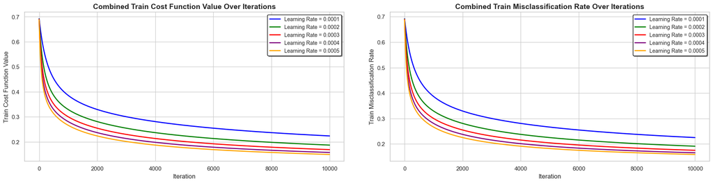

```python
# Creating the combined figure
fig, axs = plt.subplots(1, 2, figsize=(20, 6))  # One row, two columns for the combined plots

# Plotting all learning rates in the combined cost function value plot
for costs, color, lr in combined_costs_train_scaled_plots:
    axs[0].plot(costs, color=color, label=f'Learning Rate = {lr}', linewidth=2)

# Setting titles and labels for the combined cost function value plot
axs[0].set_title('Combined Train Cost Function Value Over Iterations', fontsize=14, fontweight='bold')
axs[0].set_xlabel('Iteration', fontsize=12)
axs[0].set_ylabel('Train Cost Function Value', fontsize=12)
axs[0].legend(frameon=True, shadow=True, facecolor='white', edgecolor='black', fontsize=10)

# Plotting all learning rates in the combined misclassification rate plot
for rates, color, lr in combined_rates_train_scaled_plots:
    axs[1].plot(rates, color=color, label=f'Learning Rate = {lr}', linewidth=2)

# Setting titles and labels for the combined misclassification rate plot
axs[1].set_title('Combined Train Misclassification Rate Over Iterations', fontsize=14, fontweight='bold')
axs[1].set_xlabel('Iteration', fontsize=12)
axs[1].set_ylabel('Train Misclassification Rate', fontsize=12)
axs[1].legend(frameon=True, shadow=True, facecolor='white', edgecolor='black', fontsize=10)

# Adjust layout for the combined figure
plt.tight_layout(pad=4.0)
plt.show()
```

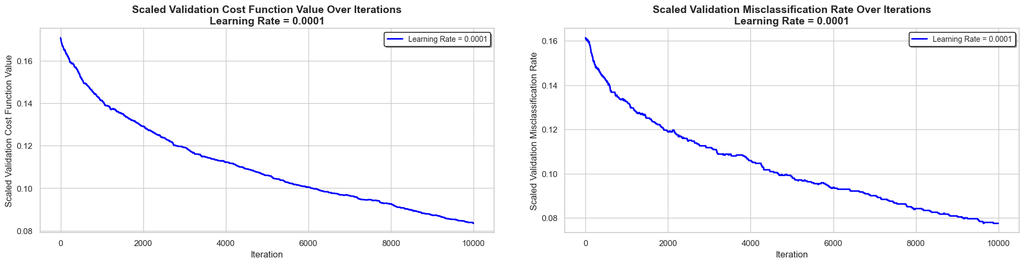

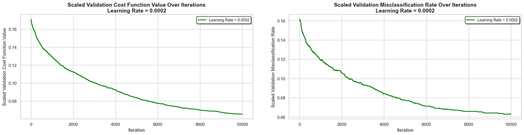

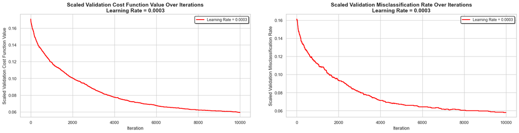

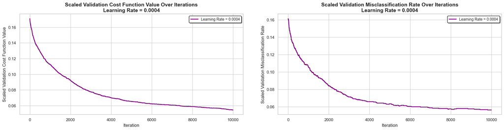

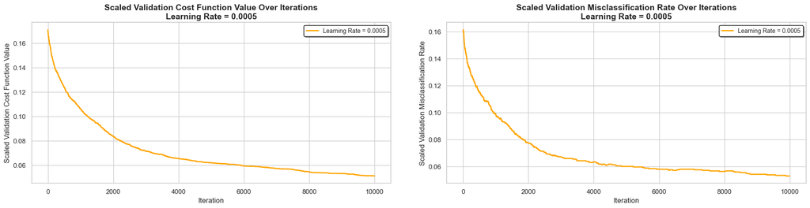

```python
# Applying a seaborn theme for nicer aesthetics
sns.set_theme(style="whitegrid")

# Define a list of colors for the plots
colors = ['blue', 'green', 'red', 'purple', 'orange', 'brown', 'pink', 'gray', 'olive', 'cyan']

# Initialize lists to store plots for the combined figure
combined_costs_val_scaled_plots = []
combined_rates_val_scaled_plots = []

# Loop through each learning rate to create a pair of plots: one for cost and one for misclassification rate
for index, (lr, costs) in enumerate(costs_val_dict.items()):
    rates = misclassification_rates_val_dict[lr]  # Assuming the structure allows direct access like this
    color = colors[index % len(colors)]  # Cycling through colors list

    # Creating a figure for the pair of plots
    fig, axs = plt.subplots(1, 2, figsize=(20, 6))  # One row, two columns

    # Plotting Train Cost Function Value Over Iterations
    axs[0].plot(costs, color=color, label=f'Learning Rate = {lr}', linewidth=2)
    axs[0].set_title(f'Scaled Validation Cost Function Value Over Iterations\nLearning Rate = {lr}', fontsize=14, fontweight='bold')
    axs[0].set_xlabel('Iteration', fontsize=12)
    axs[0].set_ylabel('Scaled Validation Cost Function Value', fontsize=12)
    axs[0].legend(frameon=True, shadow=True, facecolor='white', edgecolor='black', fontsize=10)

    # Plotting Train Misclassification Rate Over Iterations
    axs[1].plot(rates, color=color, label=f'Learning Rate = {lr}', linewidth=2)
    axs[1].set_title(f'Scaled Validation Misclassification Rate Over Iterations\nLearning Rate = {lr}', fontsize=14, fontweight='bold')
    axs[1].set_xlabel('Iteration', fontsize=12)
    axs[1].set_ylabel('Scaled Validation Misclassification Rate', fontsize=12)
    axs[1].legend(frameon=True, shadow=True, facecolor='white', edgecolor='black', fontsize=10)

    # Adjust layout
    plt.tight_layout(pad=4.0)
    plt.show()

    # For the combined plots
    combined_costs_val_scaled_plots.append((costs, color, lr))
    combined_rates_val_scaled_plots.append((rates, color, lr))
```

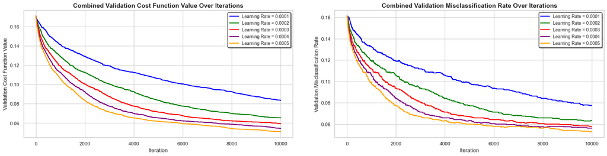

```python
# Creating the combined figure
fig, axs = plt.subplots(1, 2, figsize=(20, 6))  # One row, two columns for the combined plots

# Plotting all learning rates in the combined cost function value plot
for costs, color, lr in combined_costs_val_scaled_plots:
    axs[0].plot(costs, color=color, label=f'Learning Rate = {lr}', linewidth=2)

# Setting titles and labels for the combined cost function value plot
axs[0].set_title('Combined Validation Cost Function Value Over Iterations', fontsize=14, fontweight='bold')
axs[0].set_xlabel('Iteration', fontsize=12)
axs[0].set_ylabel('Validation Cost Function Value', fontsize=12)
axs[0].legend(frameon=True, shadow=True, facecolor='white', edgecolor='black', fontsize=10)

# Plotting all learning rates in the combined misclassification rate plot
for rates, color, lr in combined_rates_val_scaled_plots:
    axs[1].plot(rates, color=color, label=f'Learning Rate = {lr}', linewidth=2)

# Setting titles and labels for the combined misclassification rate plot
axs[1].set_title('Combined Validation Misclassification Rate Over Iterations', fontsize=14, fontweight='bold')
axs[1].set_xlabel('Iteration', fontsize=12)
axs[1].set_ylabel('Validation Misclassification Rate', fontsize=12)
axs[1].legend(frameon=True, shadow=True, facecolor='white', edgecolor='black', fontsize=10)

# Adjust layout for the combined figure
plt.tight_layout(pad=4.0)
plt.show()
```

#### D5 [10 marks]:

Set η = 10−5. Provide two (by-side) plots: training and validation sets. That is, your plot should contain two results.

```python
train_pred_dict_D5, val_pred_dict_D5, costs_train_dict_D5, misclassification_rates_train_dict_D5, costs_val_dict_D5, misclassification_rates_val_dict_D5 = {}, {}, {}, {}, {}, {}
train_pred_D5, val_pred_D5, costs_train_D5, misclassification_rate_train_D5, costs_val_D5, misclassification_rate_val_D5 = fit(X_train_scaled, y_train, X_val_scaled, y_val, learning_rate=0.00001, n_iterations=10000)

train_pred_dict_D5[0.00001] = train_pred_D5
val_pred_dict_D5[0.00001] = val_pred_D5
costs_train_dict_D5[0.00001] = costs_train_D5
misclassification_rates_train_dict_D5[0.00001] = misclassification_rate_train_D5
costs_val_dict_D5[0.00001] = costs_val_D5
misclassification_rates_val_dict_D5[0.00001] = misclassification_rate_val_D5
```

```
Iteration: 0
Iteration: 1000
Iteration: 2000
Iteration: 3000
Iteration: 4000
Iteration: 5000
Iteration: 6000
Iteration: 7000
Iteration: 8000
Iteration: 9000
```

```python
y_pred_1 = val_pred_dict_D5[0.00001].astype(int)
```

```python
y_pred_1
```

```
array([1, 0, 0, ..., 1, 0, 0])
```

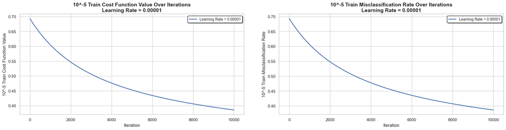

```python
# Loop through each learning rate to create a pair of plots: one for cost and one for misclassification rate
for index, (lr, costs) in enumerate(costs_train_dict_D5.items()):
    rates = misclassification_rates_train_dict_D5[lr]  # Assuming the structure allows direct access like this

    # Creating a figure for the pair of plots
    fig, axs = plt.subplots(1, 2, figsize=(20, 6))  # One row, two columns

    # Plotting Train Cost Function Value Over Iterations
    axs[0].plot(costs, label=f'Learning Rate = 0.00001', linewidth=2)
    axs[0].set_title(f'10^-5 Train Cost Function Value Over Iterations\nLearning Rate = 0.00001', fontsize=14, fontweight='bold')
    axs[0].set_xlabel('Iteration', fontsize=12)
    axs[0].set_ylabel('10^-5 Train Cost Function Value', fontsize=12)
    axs[0].legend(frameon=True, shadow=True, facecolor='white', edgecolor='black', fontsize=10)

    # Plotting Train Misclassification Rate Over Iterations
    axs[1].plot(rates, label=f'Learning Rate = 0.00001', linewidth=2)
    axs[1].set_title(f'10^-5 Train Misclassification Rate Over Iterations\nLearning Rate = 0.00001', fontsize=14, fontweight='bold')
    axs[1].set_xlabel('Iteration', fontsize=12)
    axs[1].set_ylabel('10^-5 Train Misclassification Rate', fontsize=12)
    axs[1].legend(frameon=True, shadow=True, facecolor='white', edgecolor='black', fontsize=10)

    # Adjust layout
    plt.tight_layout(pad=4.0)
    plt.show()
```

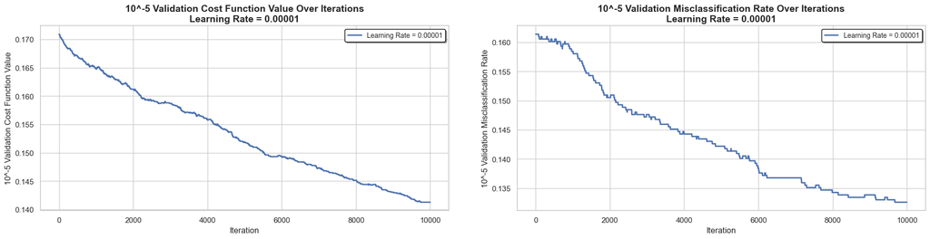

```python
# Loop through each learning rate to create a pair of plots: one for cost and one for misclassification rate
for index, (lr, costs) in enumerate(costs_val_dict_D5.items()):
    rates = misclassification_rates_val_dict_D5[lr]  # Assuming the structure allows direct access like this

    # Creating a figure for the pair of plots
    fig, axs = plt.subplots(1, 2, figsize=(20, 6))  # One row, two columns

    # Plotting Train Cost Function Value Over Iterations
    axs[0].plot(costs, label=f'Learning Rate = 0.00001', linewidth=2)
    axs[0].set_title(f'10^-5 Validation Cost Function Value Over Iterations\nLearning Rate = 0.00001', fontsize=14, fontweight='bold')
    axs[0].set_xlabel('Iteration', fontsize=12)
    axs[0].set_ylabel('10^-5 Validation Cost Function Value', fontsize=12)
    axs[0].legend(frameon=True, shadow=True, facecolor='white', edgecolor='black', fontsize=10)

    # Plotting Train Misclassification Rate Over Iterations
    axs[1].plot(rates, label=f'Learning Rate = 0.00001', linewidth=2)
    axs[1].set_title(f'10^-5 Validation Misclassification Rate Over Iterations\nLearning Rate = 0.00001', fontsize=14, fontweight='bold')
    axs[1].set_xlabel('Iteration', fontsize=12)
    axs[1].set_ylabel('10^-5 Validation Misclassification Rate', fontsize=12)
    axs[1].legend(frameon=True, shadow=True, facecolor='white', edgecolor='black', fontsize=10)

    # Adjust layout
    plt.tight_layout(pad=4.0)
    plt.show()
```

### D6 [3 marks]:

Give a short interpretation of your results. What are your conclusions?

### 4.3 Using cross-validation and Scikit-learn logistic regression classifier

You will incorporate a L2 regularisation in your model. Your first task is to select an optimal value for the regularisation hyperparameter C (the hyperparameter α in the textbook) in the training set using the fixed validation set. You must use the same number of iterations as before and explore penalty strength values in the range given by np.logspace(-10, 5, 30) (this function will generate 30 numbers spaced evenly on a log scale). Your code will look something as follows: C_range = np.logspace(-10, 5, 30) for C in C_grid: Train your model for this C value Compute the cost function on the training set Compute the cost function on the validation set

```python
# Incorparating L2 regularization
def compute_cost_L2(X, y, weights, lambda_):
    m = len(y)
    h = sigmoid(X.dot(weights))
    epsilon = 1e-5  # To prevent log(0)
    cost = (-1/m) * (y.T.dot(np.log(h + epsilon)) + (1 - y).T.dot(np.log(1 - h + epsilon)))
    reg_cost = (lambda_ / (2*m)) * np.sum(np.square(weights[1:]))  # Skip bias term for regularization
    return cost + reg_cost

def compute_gradient_L2(X, y, weights, lambda_):
    m, n = X.shape
    h = sigmoid(X.dot(weights))
    gradient = (1/m) * X.T.dot(h - y)
    reg_gradient = np.hstack([0, (lambda_ / m) * weights[1:]])  # Skip bias term for regularization
    return gradient + reg_gradient
```

```python
def fit_L2(X_train, y_train, X_val, y_val, learning_rate, n_iterations, lambda_):
    X_train = np.copy(X_train)
    X_val = np.copy(X_val)

    m, n = X_train.shape
    X_train = np.hstack([np.ones((m, 1)), X_train])  # Add bias term to training set
    m_val = X_val.shape[0]
    X_val = np.hstack([np.ones((m_val, 1)), X_val])  # Add bias term to validation set

    weights = np.zeros(n + 1)  # Initialize weights (including bias)
    train_costs = []
    val_costs = []
    train_misclassifications = []
    val_misclassifications = []

    for i in range(n_iterations):
        # Update weights using the training set
        gradients = compute_gradient_L2(X_train, y_train, weights, lambda_)
        weights -= learning_rate * gradients

        # Calculate costs
        train_cost = compute_cost_L2(X_train, y_train, weights, lambda_)
        val_cost = compute_cost_L2(X_val, y_val, weights, lambda_)
        train_costs.append(train_cost)
        val_costs.append(val_cost)

        # Calculate misclassification rates
        train_pred = predict_class(X_train, weights)
        val_pred = predict_class(X_val, weights)
        train_misclassifications.append(misclassification_rate(y_train, train_pred))
        val_misclassifications.append(misclassification_rate(y_val, val_pred))

        # Use to check speed for each 1000 iterations
        # if i % 1000 == 0:
        #     print(f"Iteration: {i}, Training Cost: {train_cost}, Validation Cost: {val_cost}")

    return train_pred, val_pred, train_costs, val_costs, train_misclassifications, val_misclassifications
```

```python
C_range = np.logspace(-10, 5, 30)

# Initialize lists to store the cost results for plotting or analysis
train_costs_results = []
val_costs_results = []
train_misclassification_results = []
val_misclassification_results = []
train_pred_results = []
test_pred_results = []


for C in C_range:
    lambda_ = 1 / C  # Convert C to lambda for the current regularization strength
    # Train the model for this lambda value
    train_pred, val_pred, train_costs, val_costs, train_misclassifications, val_misclassifications = fit_L2(X_train_scaled, y_train, X_val_scaled, y_val, learning_rate=0.01, n_iterations=10000, lambda_=lambda_)
    # Store the final cost function values for both the training and validation sets
    train_costs_results.append(train_costs[-1])
    val_costs_results.append(val_costs[-1])

    train_misclassification_results.append(train_misclassifications[-1])
    val_misclassification_results.append(val_misclassifications[-1])

    train_pred_results.append(train_pred[-1])
    test_pred_results.append(val_pred[-1])

    print(f"C={C}, Training Cost={train_costs[-1]}, Validation Cost={val_costs[-1]}")
```

```
C=1e-10, Training Cost=nan, Validation Cost=nan
C=3.290344562312671e-10, Training Cost=nan, Validation Cost=nan
C=1.0826367338740564e-09, Training Cost=nan, Validation Cost=nan
C=3.5622478902624513e-09, Training Cost=nan, Validation Cost=nan
C=1.1721022975334793e-08, Training Cost=nan, Validation Cost=nan
C=3.8566204211634724e-08, Training Cost=nan, Validation Cost=nan
C=1.2689610031679235e-07, Training Cost=nan, Validation Cost=nan
C=4.175318936560409e-07, Training Cost=nan, Validation Cost=nan
C=1.3738237958832638e-06, Training Cost=0.6371781908848951, Validation Cost=0.7690608320933872
C=4.5203536563602494e-06, Training Cost=0.5675151828560008, Validation Cost=0.7847197539318054
C=1.4873521072935119e-05, Training Cost=0.4733446086075701, Validation Cost=0.7224660523960491
C=4.893900918477499e-05, Training Cost=0.37744089825922866, Validation Cost=0.6088498354897606
C=0.00016102620275609426, Training Cost=0.2924379022161049, Validation Cost=0.4908141287551857
C=0.0005298316906283713, Training Cost=0.22236032268169892, Validation Cost=0.383971875552955
C=0.0017433288221999908, Training Cost=0.1686509315423953, Validation Cost=0.2958690536058658
C=0.005736152510448681, Training Cost=0.1301141473843476, Validation Cost=0.22844296804858416
C=0.018873918221350997, Training Cost=0.10505922356502544, Validation Cost=0.1740411498077799
C=0.06210169418915629, Training Cost=0.09249029450791747, Validation Cost=0.14044710688727155
C=0.2043359717856948, Training Cost=0.0877296709063757, Validation Cost=0.1266171273201489
C=0.6723357536499335, Training Cost=0.08616820397713428, Validation Cost=0.12195893110610259
C=2.21221629107045, Training Cost=0.08568204406201832, Validation Cost=0.12049676462777918
C=7.278953843983161, Training Cost=0.08553318819419957, Validation Cost=0.12004795793819467
C=23.950266199874907, Training Cost=0.0854878452727386, Validation Cost=0.1199111441238244
C=78.80462815669937, Training Cost=0.0854740551602695, Validation Cost=0.11986952550293313
C=259.2943797404678, Training Cost=0.08546986319628339, Validation Cost=0.11985687325662625
C=853.1678524172814, Training Cost=0.08546858909527942, Validation Cost=0.11985302766523402
C=2807.2162039411814, Training Cost=0.08546820186358572, Validation Cost=0.11985185888471044
C=9236.708571873884, Training Cost=0.08546808417561493, Validation Cost=0.11985150366668709
C=30391.953823132073, Training Cost=0.0854680484078772, Validation Cost=0.11985139570873168
C=100000.0, Training Cost=0.08546803753735692, Validation Cost=0.11985136289817662
```

#### D7 [6 marks]:

Provide two (by-side) plots: training and validation sets. That is, your plot should contain two results.

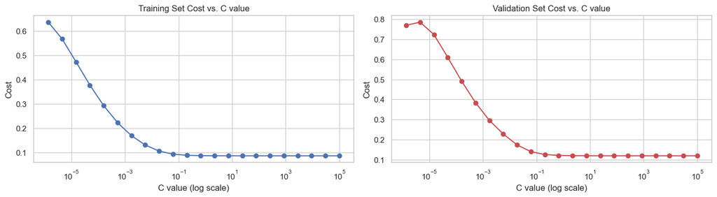

```python
# Plot for the misclassification
plt.figure(figsize=(14, 7))

# Training Set Misclassification Rate
plt.subplot(2, 2, 3)
plt.plot(C_range, train_costs_results, marker='o')
plt.xscale('log')
plt.xlabel('C value (log scale)')
plt.ylabel('Cost')
plt.title('Training Set Cost vs. C value')
plt.grid(True)

# Validation Set Misclassification Rate
plt.subplot(2, 2, 4)
plt.plot(C_range, val_costs_results, marker='o', color='r')
plt.xscale('log')
plt.xlabel('C value (log scale)')
plt.ylabel('Cost')
plt.title('Validation Set Cost vs. C value')
plt.grid(True)

plt.tight_layout()  # Adjust the layout to fit the plots
plt.show()
```

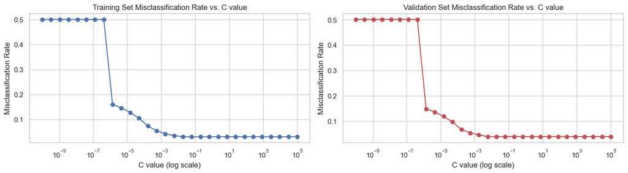

```python
# Plot for the misclassification
plt.figure(figsize=(14, 7))

# Training Set Misclassification Rate
plt.subplot(2, 2, 3)
plt.plot(C_range, train_misclassification_results, marker='o')
plt.xscale('log')
plt.xlabel('C value (log scale)')
plt.ylabel('Misclassification Rate')
plt.title('Training Set Misclassification Rate vs. C value')
plt.grid(True)

# Validation Set Misclassification Rate
plt.subplot(2, 2, 4)
plt.plot(C_range, val_misclassification_results, marker='o', color='r')
plt.xscale('log')
plt.xlabel('C value (log scale)')
plt.ylabel('Misclassification Rate')
plt.title('Validation Set Misclassification Rate vs. C value')
plt.grid(True)

plt.tight_layout()  # Adjust the layout to fit the plots
plt.show()
```

For the next task, you will use sklearn.linear model.LogisticRegressionCV, using 10- fold cross-validation and specifying the same range for the regularisation hyperparameter as before. Similarly, you will use this function to explore penalty strengths, but now using cross-validation.

#### D8 [4 marks]:

Provide two (by-side) plots:

- In the left plot, show the values of the cost function (y-axis) for each C value (x-axis). Note that you will have ten values for each C value (10 folds). Therefore, you should report the average value.
- In the right plot, show the fraction of misclassifications (y-axis) for each C value (x-axis) using the logistic regression model prediction for a threshold of 0.5.

```python
# Suppress ConvergenceWarnings
warnings.filterwarnings("ignore", category=ConvergenceWarning)

# Initialize the model with 10-fold cross-validation
model_LR2 = LogisticRegressionCV(cv=10, random_state=5508, max_iter=10000)

# Fit the model on the training data
model_LR2.fit(X_train_scaled, y_train)
```

```
LogisticRegressionCV(cv=10, max_iter=10000, random_state=5508)
```

```python
# Initialize the model with 10-fold cross-validation
model_LR2 = LogisticRegressionCV(Cs=C_range, cv=10, random_state=5508, max_iter=10000, scoring="neg_log_loss")
model_LR2.fit(X_train_scaled, y_train)

# Initialize the model for misclassification rate calculation
model_LR2_mis = LogisticRegressionCV(Cs=C_range, cv=10, random_state=5508, max_iter=10000)
model_LR2_mis.fit(X_train_scaled, y_train)
```

```
LogisticRegressionCV(Cs=array([1.00000000e-10, 3.29034456e-10, 1.08263673e-09, 3.56224789e-09,
       1.17210230e-08, 3.85662042e-08, 1.26896100e-07, 4.17531894e-07,
       1.37382380e-06, 4.52035366e-06, 1.48735211e-05, 4.89390092e-05,
       1.61026203e-04, 5.29831691e-04, 1.74332882e-03, 5.73615251e-03,
       1.88739182e-02, 6.21016942e-02, 2.04335972e-01, 6.72335754e-01,
       2.21221629e+00, 7.27895384e+00, 2.39502662e+01, 7.88046282e+01,
       2.59294380e+02, 8.53167852e+02, 2.80721620e+03, 9.23670857e+03,
       3.03919538e+04, 1.00000000e+05]),
                     cv=10, max_iter=10000, random_state=5508)
```

```python
scores = model_LR2.scores_[1]
# Compute the mean score for each C value across all folds, get the prediction results, get the misclassification rate per C
average_scores = -np.mean(scores, axis=0)
y_pred_2 = model_LR2.predict(X_val_scaled)
misclassification_rates_per_C = 1 - np.mean(model_LR2_mis.scores_[1], axis=0)

print(average_scores)
print(misclassification_rates_per_C)
print(y_pred_2)
```

```
[0.69313755 0.69311574 0.69304401 0.69280817 0.69203509 0.68951843
 0.68152265 0.65794053 0.60083762 0.5054332  0.40018297 0.30920811
 0.23529255 0.1794177  0.14201458 0.12095009 0.11364925 0.11935006
 0.13962362 0.17941888 0.23352905 0.2851683  0.32767869 0.32770436
 0.32770436 0.32770436 0.32770436 0.32770436 0.32770436 0.32770436]
[0.49968717 0.49968717 0.4995829  0.36923879 0.23441084 0.1831074
 0.17393118 0.16757039 0.16079249 0.14807091 0.13086548 0.10823775
 0.07841502 0.05912409 0.04827946 0.04212722 0.03972888 0.04014599
 0.04483837 0.04817518 0.05067779 0.05151199 0.05380605 0.05380605
 0.05380605 0.05380605 0.05380605 0.05380605 0.05380605 0.05380605]
[1 0 1 ... 1 0 0]
```

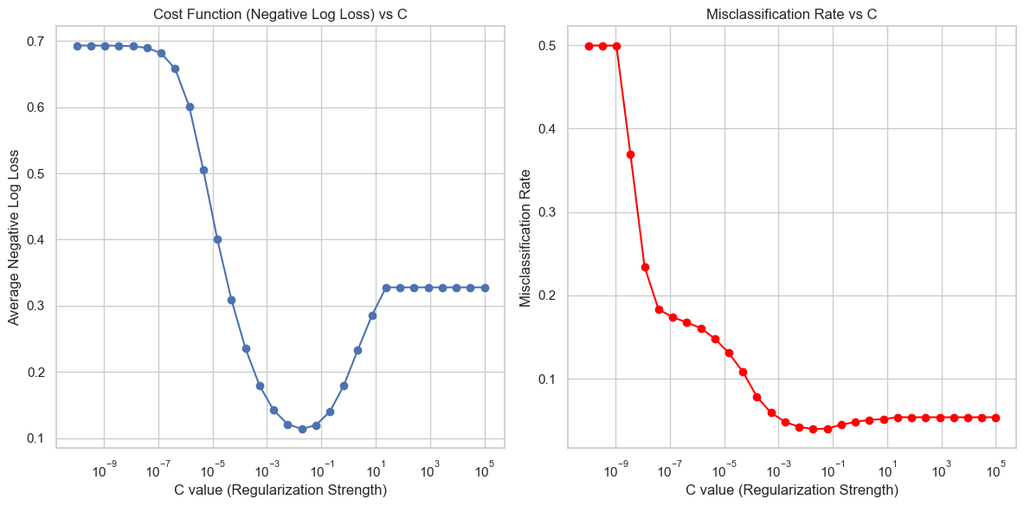

```python
# Create a figure with two subplots
fig, axes = plt.subplots(1, 2, figsize=(12, 6))

# Plot for average negative log loss
axes[0].plot(C_range, average_scores, marker='o')
axes[0].set_xscale('log')
axes[0].set_xlabel('C value (Regularization Strength)')
axes[0].set_ylabel('Average Negative Log Loss')
axes[0].set_title('Cost Function (Negative Log Loss) vs C')

# Plot for misclassification rates
axes[1].plot(C_range, misclassification_rates_per_C, marker='o', color='red')
axes[1].set_xscale('log')
axes[1].set_xlabel('C value (Regularization Strength)')
axes[1].set_ylabel('Misclassification Rate')
axes[1].set_title('Misclassification Rate vs C')

# Improve layout and display the plots
plt.tight_layout()
plt.show()
```

#### D9 [3 marks]:

Give a short interpretation of your results. Which regularisation hyperparameter value would you select and why? What was the impacting of using 10-fold cross-validation instead of a fixed validation set?

##### D9 Answer:

I would choose C as 10^-2. The misclassification rate becomes relatively flat after 10^-2, indicating that the model has reached a level of complexity that is sufficient for the given problem, and further reducing regularization does not lead to better performance. The U-shaped curve in the third plot suggests that 10^-2 is in the sweet spot where the model is complex enough to learn the underlying patterns in the data but not so complex that it starts to overfit. Hence 10^-2 will be the hyperparameter value that I will choose.

Now you will use sklearn.linear model.SDGClassifier together with sklearn.model selection.GridSearchCV to find the optimal regularisation parameter according to Grid Search. sklearn.linear model.SDGClassifier implements logistic regression “log loss”. Remember to choose the correct strategy to evaluate the performance of the cross- validated model in the scoring argument of the function. (Hint: be careful how scikit-learn defines the Grid Search).

```python
# Suppress FutureWarnings
warnings.filterwarnings("ignore", category=FutureWarning)

# Define the model and parameter grid
model_LR3 = SGDClassifier(loss='log_loss', max_iter=10000, tol=1e-3, random_state=5508)

# Define the parameter grid to search over
param_grid = {
    'alpha': C_range,  # Regularization strength
}

scoring = {'log_loss': make_scorer(log_loss, greater_is_better=False, needs_proba=True),
           'accuracy': 'accuracy'}

model_LR3.fit(X_train_scaled, y_train)
```

```
SGDClassifier(loss='log_loss', max_iter=10000, random_state=5508)
```

```python
y_pred_3 = model_LR3.predict(X_val_scaled)
y_pred_proba_3 = model_LR3.predict_proba(X_val_scaled)[:, 1]
```

```python
grid_search = GridSearchCV(model_LR3, param_grid, scoring=scoring, refit='log_loss', return_train_score=True, cv=10)
grid_search.fit(X_train_scaled, y_train)
```

```
GridSearchCV(cv=10,
             estimator=SGDClassifier(loss='log_loss', max_iter=10000,
                                     random_state=5508),
             param_grid={'alpha': array([1.00000000e-10, 3.29034456e-10, 1.08263673e-09, 3.56224789e-09,
       1.17210230e-08, 3.85662042e-08, 1.26896100e-07, 4.17531894e-07,
       1.37382380e-06, 4.52035366e-06, 1.48735211e-05, 4.89390092e-05,
       1.61026203e-04, 5.29831691e-04, 1.74332882e-03, 5.736...
       1.88739182e-02, 6.21016942e-02, 2.04335972e-01, 6.72335754e-01,
       2.21221629e+00, 7.27895384e+00, 2.39502662e+01, 7.88046282e+01,
       2.59294380e+02, 8.53167852e+02, 2.80721620e+03, 9.23670857e+03,
       3.03919538e+04, 1.00000000e+05])},
             refit='log_loss', return_train_score=True,
             scoring={'accuracy': 'accuracy',
                      'log_loss': make_scorer(log_loss, greater_is_better=False, response_method='predict_proba')})
```

#### D10 [5 marks]:

In a table, report:

- The optimal value of the regularisation hyperparameter C according to Grid Search; • The value of the cost function in the training set for this optimal value;
- The value of the cost function in the validation set;
- The fraction of misclassifications in the training set;
- The fraction of the misclassifications in the validation set.

```python
best_model = grid_search.best_estimator_
best_alpha = grid_search.best_params_['alpha']
train_loss = -grid_search.cv_results_['mean_train_log_loss'][grid_search.best_index_]
test_loss = -grid_search.cv_results_['mean_test_log_loss'][grid_search.best_index_]
train_accuracy = grid_search.cv_results_['mean_train_accuracy'][grid_search.best_index_]
test_accuracy = grid_search.cv_results_['mean_test_accuracy'][grid_search.best_index_]

# Calculate the fraction of misclassifications
train_misclassification = 1 - train_accuracy
test_misclassification = 1 - test_accuracy

# Reporting the results
results = {
    'Optimal C': 1.0/best_alpha,
    'Train Loss': train_loss,
    'Validation Loss': test_loss,
    'Train Misclassification Fraction': train_misclassification,
    'Validation Misclassification Fraction': test_misclassification
}
```

```python
results_df = pd.DataFrame([results])
results_df
```

|  | Optimal C | Train Loss | Validation Loss | Train Misclassification Fraction | Validation Misclassification Fraction |
| --- | --- | --- | --- | --- | --- |
| 0 | 52.983169 | 0.108462 | 0.136323 | 0.034179 | 0.041084 |

#### D11 [3 marks]:

Give a short interpretation of your results. How do they compare with what you obtained in task D8?

##### D11 Answer:

The actual optimal C value from the results is much higher than what was estimated from the plots. In the plots, the curve began to plateau around C=10^-2, but the value from the results suggests that a much higher C, implying less regularization, is optimal according to the cross-validation procedure used.

This would suggest that the model requires less regularization than initially thought, perhaps due to the inherent complexity of the dataset or its size. These results are valuable as they provide a concrete C value to use for this model, along with performance metrics that suggest good generalization from training to unseen data.

Select the model you just created using sklearn.linear model.SDGClassifier together with sklearn.model selection.GridSearchCV; that is, using the optimal value of the regularisation hyperparameter C according to Grid Search.

```python
# Define and train the SGDClassifier model with the optimal alpha
model_LR4 = SGDClassifier(loss='log_loss', alpha=best_alpha, max_iter=10000, tol=1e-3, random_state=5508)
model_LR4.fit(X_train_scaled, y_train)
```

```
SGDClassifier(alpha=0.018873918221350997, loss='log_loss', max_iter=10000,
              random_state=5508)
```

```python
# Get prediction probability for SGDC model
y_pred_proba_4 = model_LR4.predict_proba(X_val_scaled)[:, 1]
y_pred_4 = model_LR4.predict(X_val_scaled)
```

#### D12 [5 marks]:

With the obtained C, train your model using the training set. Predict the examples in the validation set, plot precision versus recall for different threshold values and comment on the results. How does the performance measure behave? What threshold would you choose and why?

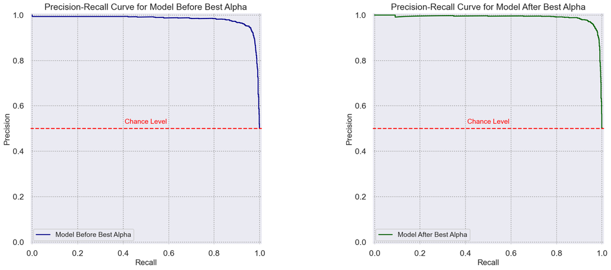

```python
# Calculate precision-recall curves
precision_3, recall_3, thresholds_3 = precision_recall_curve(y_val, y_pred_proba_3)
precision_4, recall_4, thresholds_4 = precision_recall_curve(y_val, y_pred_proba_4)

# Set style for the plots
sns.set_context("talk")  # Makes labels and lines larger
sns.set_style("darkgrid", {"grid.color": ".6", "grid.linestyle": ":"})

# Create subplots
fig, ax = plt.subplots(1, 2, figsize=(20, 8))

# Plot the Precision-Recall curve for y_pred_proba_3
display_3 = PrecisionRecallDisplay(precision=precision_3, recall=recall_3, estimator_name='Model Before Best Alpha')
display_3.plot(ax=ax[0], color='darkblue', linewidth=2)

# Plot the Precision-Recall curve for y_pred_proba_4
display_4 = PrecisionRecallDisplay(precision=precision_4, recall=recall_4, estimator_name='Model After Best Alpha')
display_4.plot(ax=ax[1], color='darkgreen', linewidth=2)

# Enhancements for aesthetics
ax[0].set_title('Precision-Recall Curve for Model Before Best Alpha', fontsize=18)
ax[0].set_xlabel('Recall', fontsize=16)
ax[0].set_ylabel('Precision', fontsize=16)
ax[0].legend(loc='best', fontsize=14)

ax[1].set_title('Precision-Recall Curve for Model After Best Alpha', fontsize=18)
ax[1].set_xlabel('Recall', fontsize=16)
ax[1].set_ylabel('Precision', fontsize=16)
ax[1].legend(loc='best', fontsize=14)

# Add a line for random guessing (chance level) and annotate
chance_level = y_val.mean()
for a in ax:
    a.axhline(chance_level, linestyle='--', color='red', linewidth=2)
    a.text(0.5, chance_level + 0.02, 'Chance Level', color='red', ha='center', fontsize=14)

plt.tight_layout()
plt.show()
```

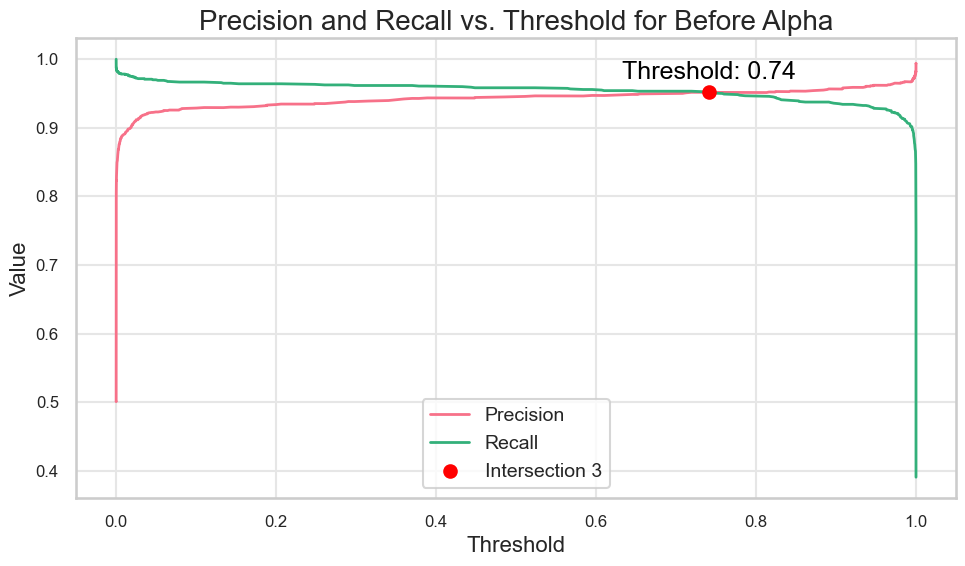

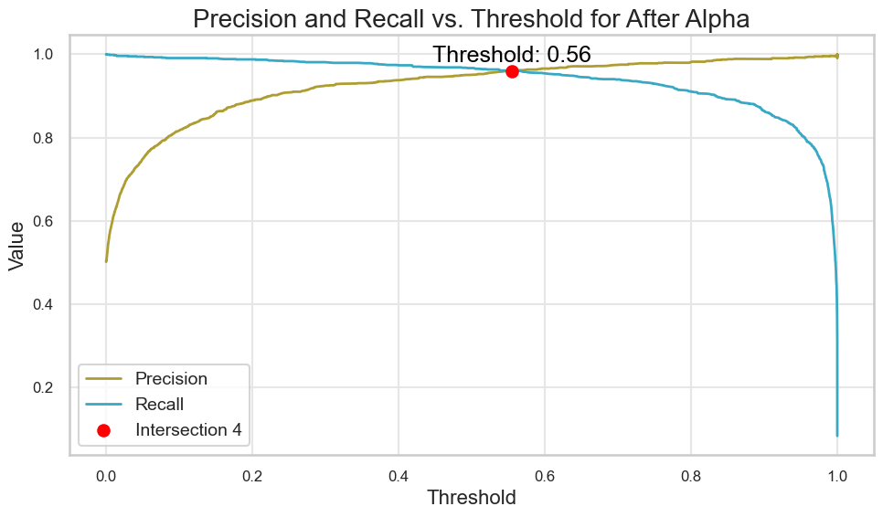

```python
# Compute precision-recall curve for predictions 3
precision3, recall3, thresholds3 = precision_recall_curve(y_val, y_pred_proba_3)
equal_index3 = np.argmax(precision3 >= recall3)
intersection_point3 = (precision3[equal_index3], recall3[equal_index3])

# Compute precision-recall curve for predictions 4
precision4, recall4, thresholds4 = precision_recall_curve(y_val, y_pred_proba_4)
equal_index4 = np.argmax(precision4 >= recall4)
intersection_point4 = (precision4[equal_index4], recall4[equal_index4])

# Set the style for the plots
sns.set_context("talk")  # Makes labels and lines larger
sns.set_style("whitegrid", {"grid.color": ".9", "grid.linestyle": "-"})

# Create a color palette
palette = sns.color_palette("husl", 5)

# Plot for predictions 3
plt.figure(figsize=(10, 6))
plt.plot(thresholds3, precision3[:-1], label="Precision", linewidth=2, color=palette[0])
plt.plot(thresholds3, recall3[:-1], label="Recall", linewidth=2, color=palette[2])
plt.scatter(thresholds3[equal_index3], intersection_point3[0], color='red', label='Intersection 3', zorder=5)
plt.text(thresholds3[equal_index3], intersection_point3[0] + 0.02, f'Threshold: {thresholds3[equal_index3]:.2f}', ha='center', color='black')

# Aestatic configuration
plt.title('Precision and Recall vs. Threshold for Before Alpha', fontsize=20)
plt.xlabel('Threshold', fontsize=16)
plt.ylabel('Value', fontsize=16)
plt.legend(loc='best', fontsize=14)
plt.xticks(fontsize=12)
plt.yticks(fontsize=12)
plt.tight_layout()
plt.grid(True)
plt.show()

# Plot for predictions 4
plt.figure(figsize=(10, 6))
plt.plot(thresholds4, precision4[:-1], label="Precision", linewidth=2, color=palette[1])
plt.plot(thresholds4, recall4[:-1], label="Recall", linewidth=2, color=palette[3])
plt.scatter(thresholds4[equal_index4], intersection_point4[0], color='red', label='Intersection 4', zorder=5)
plt.text(thresholds4[equal_index4], intersection_point4[0] + 0.02, f'Threshold: {thresholds4[equal_index4]:.2f}', ha='center', color='black')

# Aestatic configuration
plt.title('Precision and Recall vs. Threshold for After Alpha', fontsize=20)
plt.xlabel('Threshold', fontsize=16)
plt.ylabel('Value', fontsize=16)
plt.legend(loc='best', fontsize=14)
plt.xticks(fontsize=12)
plt.yticks(fontsize=12)
plt.tight_layout()
plt.grid(True)
plt.show()
```